# Assignment 2

Before working on this assignment please read these instructions fully. In the submission area, you will notice that you can click the link to **Preview the Grading** for each step of the assignment. This is the criteria that will be used for peer grading. Please familiarize yourself with the criteria before beginning the assignment.

An NOAA dataset has been stored in the file `data/C2A2_data/BinnedCsvs_d400/fb441e62df2d58994928907a91895ec62c2c42e6cd075c2700843b89.csv`. The data for this assignment comes from a subset of The National Centers for Environmental Information (NCEI) [Daily Global Historical Climatology Network](https://www1.ncdc.noaa.gov/pub/data/ghcn/daily/readme.txt) (GHCN-Daily). The GHCN-Daily is comprised of daily climate records from thousands of land surface stations across the globe.

Each row in the assignment datafile corresponds to a single observation.

The following variables are provided to you:

- **id** : station identification code
- **date** : date in YYYY-MM-DD format (e.g. 2012-01-24 = January 24, 2012)
- **element** : indicator of element type
  - TMAX : Maximum temperature (tenths of degrees C)
  - TMIN : Minimum temperature (tenths of degrees C)
- **value** : data value for element (tenths of degrees C)

For this assignment, you must:

1. Read the documentation and familiarize yourself with the dataset, then write some python code which returns a line graph of the record high and record low temperatures by day of the year over the period 2005-2014. The area between the record high and record low temperatures for each day should be shaded.
2. Overlay a scatter of the 2015 data for any points (highs and lows) for which the ten year record (2005-2014) record high or record low was broken in 2015.
3. Watch out for leap days (i.e. February 29th), it is reasonable to remove these points from the dataset for the purpose of this visualization.
4. Make the visual nice! Leverage principles from the first module in this course when developing your solution. Consider issues such as legends, labels, and chart junk.

The data you have been given is near **Ann Arbor, Michigan, United States**, and the stations the data comes from are shown on the map below.

```python
import matplotlib.pyplot as plt
import mplleaflet
import pandas as pd

def leaflet_plot_stations(binsize, hashid):

    df = pd.read_csv('data/C2A2_data/BinSize_d{}.csv'.format(binsize))

    station_locations_by_hash = df[df['hash'] == hashid]

    lons = station_locations_by_hash['LONGITUDE'].tolist()
    lats = station_locations_by_hash['LATITUDE'].tolist()

    plt.figure(figsize=(8,8))

    plt.scatter(lons, lats, c='r', alpha=0.7, s=200)

    return mplleaflet.display()

leaflet_plot_stations(400,'fb441e62df2d58994928907a91895ec62c2c42e6cd075c2700843b89')
```

[interactive chart not shown]

# Plotting Weather Patterns

```
Author: Shanlang Liu
Date: 2019-Jul-25
```

```python
import matplotlib.pyplot as plt
import numpy as np
import pandas as pd
from matplotlib.dates import DateFormatter, MonthLocator
```

```python
df = pd.read_csv('data/C2A2_data/BinnedCsvs_d400/fb441e62df2d58994928907a91895ec62c2c42e6cd075c2700843b89.csv')
df.head()
```

|  | ID | Date | Element | Data_Value |
| --- | --- | --- | --- | --- |
| 0 | USW00094889 | 2014-11-12 | TMAX | 22 |
| 1 | USC00208972 | 2009-04-29 | TMIN | 56 |
| 2 | USC00200032 | 2008-05-26 | TMAX | 278 |
| 3 | USC00205563 | 2005-11-11 | TMAX | 139 |
| 4 | USC00200230 | 2014-02-27 | TMAX | -106 |

```python
df['Date'] = pd.to_datetime(df['Date'])
df['Year'] = df['Date'].dt.year
df['Month-Day'] = df['Date'].dt.strftime('%m-%d')

# Convert to degrees C
df['Data_Value'] = df['Data_Value'] / 10

# Remove leap year days
df = df[df['Month-Day'] != '02-29']

# Split 2015 data
df_2015 = df[df['Year'] == 2015]
df = df[df['Year'] < 2015]

# Record high and low from 2005 to 2014
high = df[df['Element'] == 'TMAX'].groupby('Month-Day').max()['Data_Value']
low = df[df['Element'] == 'TMIN'].groupby('Month-Day').min()['Data_Value']

# Record high and low in 2015
high_2015 = df_2015[df_2015['Element'] == 'TMAX'].groupby('Month-Day').max()['Data_Value']
low_2015 = df_2015[df_2015['Element'] == 'TMIN'].groupby('Month-Day').min()['Data_Value']

# Concatenate all the 4 series
df = pd.concat([high, low, high_2015, low_2015], axis = 1)
df.columns = ['High', 'Low', 'High_2015', 'Low_2015']

# Identify the broken record
df['High_Broken'] = df[df['High_2015'] > df['High']]['High_2015']
df['Low_Broken'] = df[df['Low_2015'] < df['Low']]['Low_2015']

df = df.reset_index()

df.head()
```

|  | Month-Day | High | Low | High_2015 | Low_2015 | High_Broken | Low_Broken |
| --- | --- | --- | --- | --- | --- | --- | --- |
| 0 | 01-01 | 15.6 | -16.0 | 1.1 | -13.3 | NaN | NaN |
| 1 | 01-02 | 13.9 | -26.7 | 3.9 | -12.2 | NaN | NaN |
| 2 | 01-03 | 13.3 | -26.7 | 3.9 | -6.7 | NaN | NaN |
| 3 | 01-04 | 10.6 | -26.1 | 4.4 | -8.8 | NaN | NaN |
| 4 | 01-05 | 12.8 | -15.0 | 2.8 | -15.5 | NaN | -15.5 |

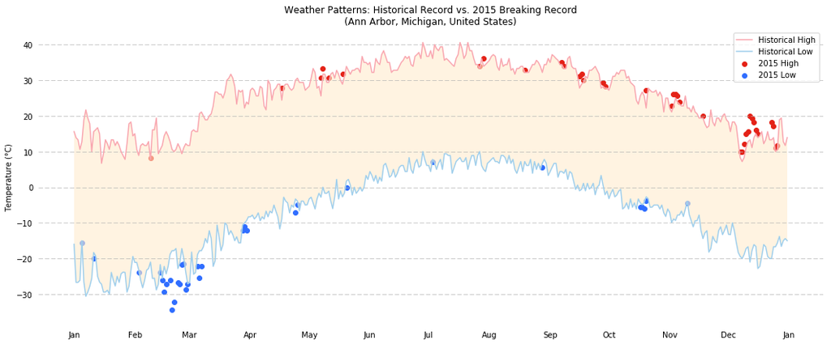

```python
%matplotlib notebook

plt.figure(figsize = (18, 7))

x_range = np.arange('2015-01-01', '2016-01-01', dtype = 'datetime64')

# Record high
plt.plot(x_range, df['High'], color = '#F9A7B0')
''' Lava Red: #E42217
    Flamingo Pink #F9A7B0
    Pink Bubble Gum #FFDFDD '''

# Record low
plt.plot(x_range, df['Low'], color = '#A0CFEC')
''' Blue Ribbon: #306EFF
    Jeans Blue: #A0CFEC
    Robin Egg Blue: #BDEDFF '''

# Overlay 2015 data where records are broken
plt.scatter(x_range, df['High_Broken'], color = '#E42217')
plt.scatter(x_range, df['Low_Broken'], color = '#306EFF')

# Fill it up
ax = plt.gca()
ax.fill_between(x_range, df['High'], df['Low'], facecolor = '#FFEBCD', alpha = 0.6)
''' Platinum: #E5E4E2
    Cornsilk: #FFF8DC
    Blached Almond: #FFEBCD'''

# Clean it up
[plt.gca().spines[loc].set_visible(False) for loc in ['left', 'right', 'bottom', 'top']]
plt.tick_params(top='off', bottom='off', left='off', right='off')

# Label it up
plt.legend(['Historical High', 'Historical Low', '2015 High', '2015 Low'])
plt.title('Weather Patterns: Historical Record vs. 2015 Breaking Record' + '\n' + '(Ann Arbor, Michigan, United States)')
plt.ylabel('Temperature (°C)')
plt.axes().yaxis.grid(linestyle = '--', alpha = 0.8)

# Convert x-axis value to month
ax.xaxis.set_major_locator(MonthLocator())
ax.xaxis.set_major_formatter(DateFormatter('%b'))


plt.show()
```

```python
# Export high quality image
plt.savefig('weather patterns.svg', dpi = 1200)
```